# Introduction

## Outline

1. Theory
2. Results
3. Conclusion

## 1. Theory

### 1. 1 Text and formula

We can place as many Markdown chunks into the script as needed. They can be used to style and structure the text. The finished script can be rendered to HTML and PDF and the renderer will use a LaTeX-like syntax to render formulas into the document.

From the very same script document, we can compile a set of slides. We simply need to adjust for each chunk if it should be a slide on its own, a subslide or fragment of a slide. Alternatively, we can also ignore chunks in case they are just meant to be used in a full featured script document. This chunk is set to be skipped and will not render into slides. Then in the next chunk, we can just place the important stuff.

We can place **styled** *text* here, or even render a formula: $$ E = mc^2$$ Formulas can also go $in = li + ne$

### 1.2 Code

We can also place some Code chunks into the document. They are run at compile time. Let's set up some variables in Octave.

```matlab
m = 78000       % [g]
c = 300000000   % [m/s]
```

[output not shown]

## 2. Results

### 2.1 Apply the model

We apply the given model:

$$ E = mc^2 $$

and print the result to the screen

```matlab
E = m * c^2
```

[output not shown]

### 2.2 Plotting

What about applying the model to different input values and plotting them?

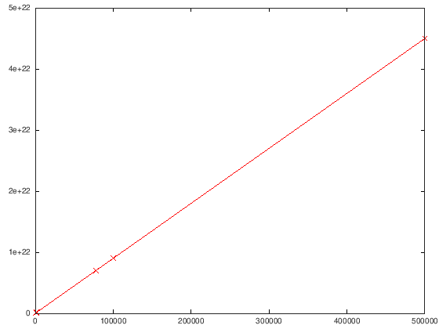

```matlab
m = [1000 1500 2000 78000 100000 500000];
E = m * c^2;

figure;
plot(m, E, 'x-r');
```

## 3. Conclusion

Well, that plot was neither surprising nor impressive. But I hope you got the point how a script like this could be brought to life.